# Lab 4

## Lab 4

**Question 1.**

```r
if (!file.exists("met_all.gz"))
  download.file(
    url = "https://raw.githubusercontent.com/USCbiostats/data-science-data/master/02_met/met_all.gz",
    destfile = "met_all.gz",
    method   = "libcurl",
    timeout  = 60
  )
met <- read.csv("met_all.gz")
```

**Question 2.**

```r
met <- met[met$temp > -17, ]
met$elev[met$elev==9999.0] <- NA
met$date <- as.Date(paste(met$year, met$month, met$day, sep = "-"))
met <- subset(met, day <=7)

library(dplyr)
met_avg <- summarize(met,
                     temp =     mean(temp, na.rm = TRUE),
                     rh =       mean(rh, na.rm = TRUE),
                     wind.sp =  mean(wind.sp, na.rm = TRUE),
                     vis.dist = mean(vis.dist, na.rm = TRUE),
                     dew.point = mean(dew.point, na.rm = TRUE),
                     lat =      mean(lat, na.rm = TRUE),
                     lon =      mean(lon, na.rm = TRUE),
                     elev =     mean(elev, na.rm = TRUE),
                     .by = c(USAFID))

met_avg$region <- NA
met_avg$region[met_avg$lon < -98 & met_avg$lat >= 39.71 ] <- "NW"
met_avg$region[met_avg$lon < -98 & met_avg$lat < 39.71 ] <- "SW"
met_avg$region[met_avg$lon >= -98 & met_avg$lat >= 39.71 ] <- "NE"
met_avg$region[met_avg$lon >= -98 & met_avg$lat < 39.71 ] <- "SE"

met_avg$elev_cat <- ifelse(met_avg$elev > 252, "high", "low")
```

**Question 3.**

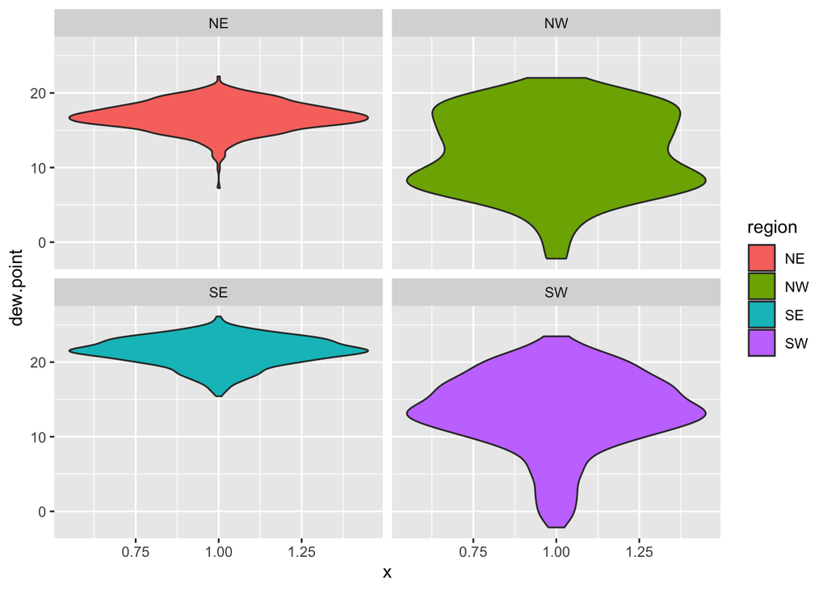

```r
library(tidyverse)
met_avg[
  !is.na(met_avg$dew.point) &
    !is.na(met_avg$region),
] %>%
  ggplot() +
  geom_violin(
    mapping = aes(x = 1, y = dew.point, fill = region)
  ) +
  facet_wrap(~region)
```

**Question 4.**

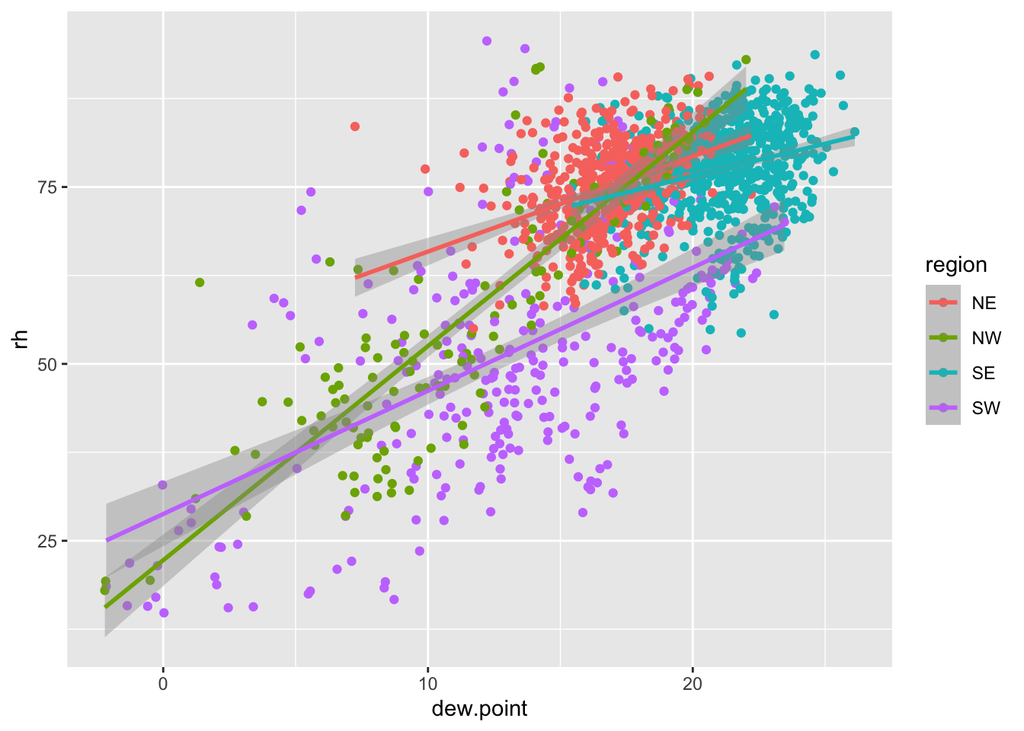

```r
met_avg[
  !is.na(met_avg$region) &
    !is.na(met_avg$dew.point) &
    !is.na(met_avg$rh),
] %>%
  ggplot() +
  geom_point(
    mapping = aes(
      x = dew.point,
      y = rh,
      color = region
    )
  ) +
  stat_smooth(
    mapping = aes(
      x = dew.point,
      y = rh,
      color = region
    ),
    method = "lm"
  )
```

The relative humidity is plotted on the y-axis, and dew-point is plotted on the x-axis, with all regions in a different color. We can see that the line for the western regions is way longer, thus it has a wider range in dew point compared to the eastern regions. They also have a wider range for relative humidity.

**Question 5.**

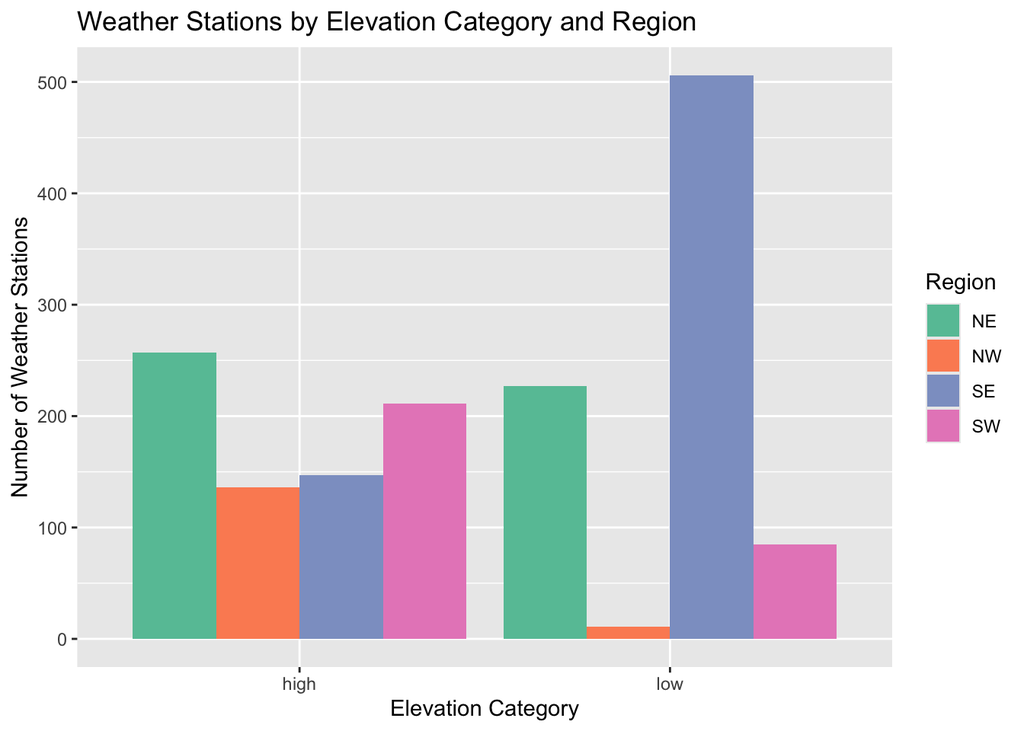

```r
met_avg[
  !is.na(met_avg$elev_cat) &
    !is.na(met_avg$region),
] %>%
  ggplot() +
  geom_bar(
    mapping = aes(x = elev_cat, fill = region),
    position = "dodge"
  ) +
  scale_fill_brewer(palette = "Set2") +
  labs(
    title = "Weather Stations by Elevation Category and Region",
    x = "Elevation Category",
    y = "Number of Weather Stations",
    fill = "Region"
  )
```

This shows that the SE has a bunch of low elevation weather stations, and that the NW has very little low elevation weather stations. Across high elevations, the spread between number of weather stations for all regions is a little bit more even.

**Question 6.**

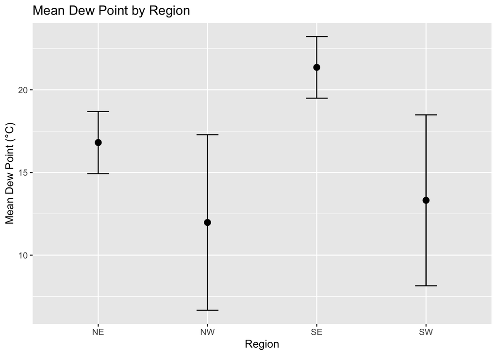

```r
dew_plot <- met_avg[
  !is.na(met_avg$region) &
    !is.na(met_avg$dew.point),
] %>%
  ggplot() +
  stat_summary(
    mapping = aes(x = region, y = dew.point),
    fun.data = "mean_sdl",
    fun.args = list(mult = 1)
  ) +
  stat_summary(
    mapping = aes(x = region, y = dew.point),
    fun.data = "mean_sdl",
    fun.args = list(mult = 1),
    geom = "errorbar",
    width = 0.2
  ) +
  labs(
    title = "Mean Dew Point by Region",
    x = "Region",
    y = "Mean Dew Point (°C)"
  )

dew_plot
```

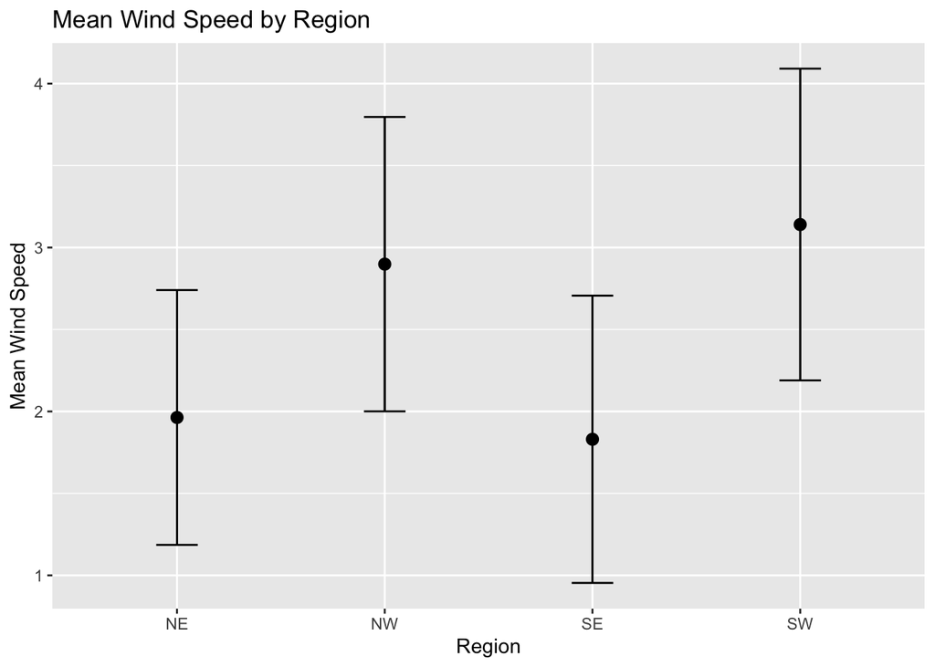

```r
wind_plot <- met_avg[
  !is.na(met_avg$region) &
    !is.na(met_avg$wind.sp),
] %>%
  ggplot() +
  stat_summary(
    mapping = aes(x = region, y = wind.sp),
    fun.data = "mean_sdl",
    fun.args = list(mult = 1)
  ) +
  stat_summary(
    mapping = aes(x = region, y = wind.sp),
    fun.data = "mean_sdl",
    fun.args = list(mult = 1),
    geom = "errorbar",
    width = 0.2
  ) +
  labs(
    title = "Mean Wind Speed by Region",
    x = "Region",
    y = "Mean Wind Speed"
  )

wind_plot
```

Mean dew point is the highest in the SE region, and has the biggest variability in NW region.

Wind speed is the highest in SW region. NE and SE wind speeds are pretty similar.

**Question 7**

```r
library(leaflet)

met_avg2 <- summarize(
  met,
  rh  = mean(rh, na.rm = TRUE),
  lat = mean(lat, na.rm = TRUE),
  lon = mean(lon, na.rm = TRUE),
  .by = USAFID
)

met_avg2 <- met_avg2[
  !is.na(met_avg2$rh) &
    !is.na(met_avg2$lat) &
    !is.na(met_avg2$lon),
]

rh.pal <- colorNumeric(
  c("goldenrod", "lightgreen", "darkgreen", "blue"),
  domain = met_avg2$rh
)

rh.pal(50)
```

```
[1] "#69C265"
```

```r
rhmap <- leaflet(met_avg2) %>%
  addProviderTiles("CartoDB.Positron") %>%

  addCircles(
    lat = ~lat,
    lng = ~lon,
    label = ~paste0(round(rh, 2), "% RH"),
    color = ~rh.pal(rh),
    opacity = 1,
    fillOpacity = 1,
    radius = 5000
  ) %>%

  addMarkers(
    data = met_avg2[rank(-met_avg2$rh) <= 10, ],
    lat = ~lat,
    lng = ~lon,
    label = ~paste0(
      "Top 10 RH: ",
      round(rh, 2),
      "%"
    )
  ) %>%

  addLegend(
    "bottomleft",
    pal = rh.pal,
    values = met_avg2$rh,
    title = "Relative Humidity (%)",
    opacity = 1
  )

rhmap
```

[interactive chart not shown]

The overall trend among relative humidity is that it gets higher when going east.

**Question 8**

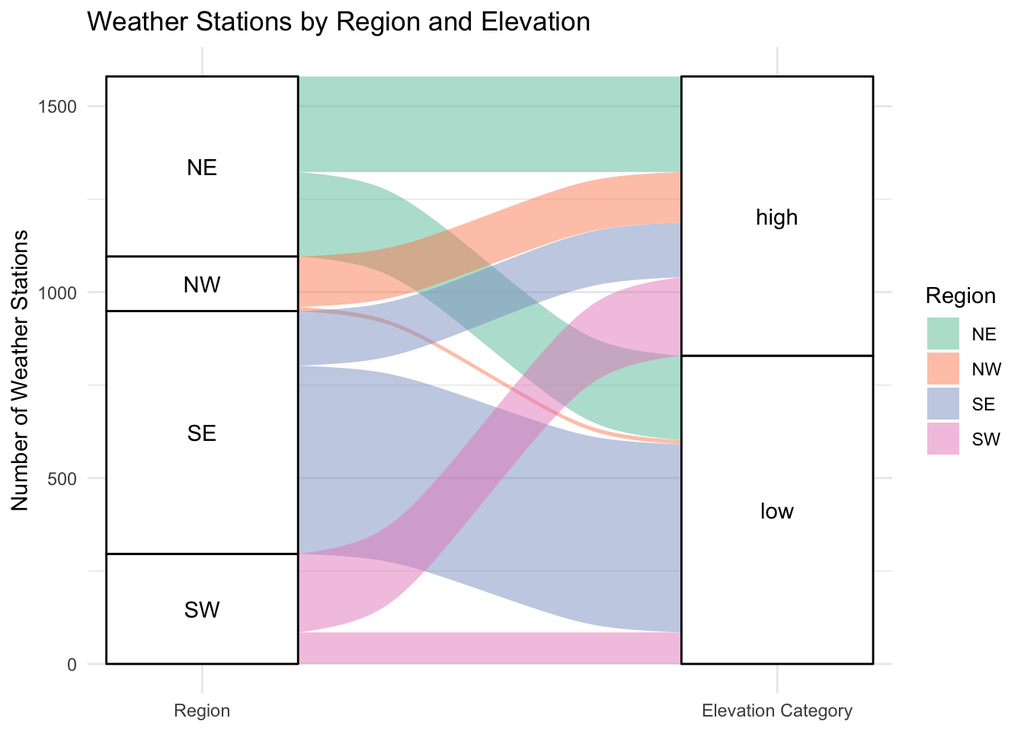

```r
library(ggalluvial)

elevation_counts <- met_avg[
  !is.na(met_avg$region) &
    !is.na(met_avg$elev_cat),
] %>%
  count(region, elev_cat)

ggplot(
  elevation_counts,
  aes(
    axis1 = region,
    axis2 = elev_cat,
    y = n
  )
) +
  geom_alluvium(aes(fill = region)) +
  geom_stratum() +
  geom_text(
    stat = "stratum",
    aes(label = after_stat(stratum))
  ) +
  scale_x_discrete(
    limits = c("Region", "Elevation Category"),
    expand = c(0.1, 0.1)
  ) +
  scale_fill_brewer(palette = "Set2") +
  labs(
    title = "Weather Stations by Region and Elevation",
    x = NULL,
    y = "Number of Weather Stations",
    fill = "Region"
  ) +
  theme_minimal()
```